# 실습과제

## 3번

### state.x77 데이터셋 분석

#### state.x77 데이터셋의 각 변수값에 대해 조사하시오.

```r
?state.x77
```

```
## starting httpd help server ... done
```

#### state.x77 데이터셋의 데이터 프레임을 분석하시오.

```r
st <- as.data.frame(state.x77)
st
```

```
##                Population Income Illiteracy Life Exp Murder HS Grad Frost
## Alabama              3615   3624        2.1    69.05   15.1    41.3    20
## Alaska                365   6315        1.5    69.31   11.3    66.7   152
## Arizona              2212   4530        1.8    70.55    7.8    58.1    15
## Arkansas             2110   3378        1.9    70.66   10.1    39.9    65
## California          21198   5114        1.1    71.71   10.3    62.6    20
## Colorado             2541   4884        0.7    72.06    6.8    63.9   166
## Connecticut          3100   5348        1.1    72.48    3.1    56.0   139
## Delaware              579   4809        0.9    70.06    6.2    54.6   103
## Florida              8277   4815        1.3    70.66   10.7    52.6    11
## Georgia              4931   4091        2.0    68.54   13.9    40.6    60
## Hawaii                868   4963        1.9    73.60    6.2    61.9     0
## Idaho                 813   4119        0.6    71.87    5.3    59.5   126
## Illinois            11197   5107        0.9    70.14   10.3    52.6   127
## Indiana              5313   4458        0.7    70.88    7.1    52.9   122
## Iowa                 2861   4628        0.5    72.56    2.3    59.0   140
## Kansas               2280   4669        0.6    72.58    4.5    59.9   114
## Kentucky             3387   3712        1.6    70.10   10.6    38.5    95
## Louisiana            3806   3545        2.8    68.76   13.2    42.2    12
## Maine                1058   3694        0.7    70.39    2.7    54.7   161
## Maryland             4122   5299        0.9    70.22    8.5    52.3   101
## Massachusetts        5814   4755        1.1    71.83    3.3    58.5   103
## Michigan             9111   4751        0.9    70.63   11.1    52.8   125
## Minnesota            3921   4675        0.6    72.96    2.3    57.6   160
## Mississippi          2341   3098        2.4    68.09   12.5    41.0    50
## Missouri             4767   4254        0.8    70.69    9.3    48.8   108
## Montana               746   4347        0.6    70.56    5.0    59.2   155
## Nebraska             1544   4508        0.6    72.60    2.9    59.3   139
## Nevada                590   5149        0.5    69.03   11.5    65.2   188
## New Hampshire         812   4281        0.7    71.23    3.3    57.6   174
## New Jersey           7333   5237        1.1    70.93    5.2    52.5   115
## New Mexico           1144   3601        2.2    70.32    9.7    55.2   120
## New York            18076   4903        1.4    70.55   10.9    52.7    82
## North Carolina       5441   3875        1.8    69.21   11.1    38.5    80
## North Dakota          637   5087        0.8    72.78    1.4    50.3   186
## Ohio                10735   4561        0.8    70.82    7.4    53.2   124
## Oklahoma             2715   3983        1.1    71.42    6.4    51.6    82
## Oregon               2284   4660        0.6    72.13    4.2    60.0    44
## Pennsylvania        11860   4449        1.0    70.43    6.1    50.2   126
## Rhode Island          931   4558        1.3    71.90    2.4    46.4   127
```

[output cut: 47 more lines]

```
## Oklahoma        68782
## Oregon          96184
## Pennsylvania    44966
## Rhode Island     1049
## South Carolina  30225
## South Dakota    75955
## Tennessee       41328
## Texas          262134
## Utah            82096
## Vermont          9267
## Virginia        39780
## Washington      66570
## West Virginia   24070
## Wisconsin       54464
## Wyoming         97203
```

#### state.x77 데이터셋의 각 변수별 기술적 통계량을 분석하시오.

```r
summary(st)
```

```
##    Population        Income       Illiteracy       Life Exp
##  Min.   :  365   Min.   :3098   Min.   :0.500   Min.   :67.96
##  1st Qu.: 1080   1st Qu.:3993   1st Qu.:0.625   1st Qu.:70.12
##  Median : 2838   Median :4519   Median :0.950   Median :70.67
##  Mean   : 4246   Mean   :4436   Mean   :1.170   Mean   :70.88
##  3rd Qu.: 4968   3rd Qu.:4814   3rd Qu.:1.575   3rd Qu.:71.89
##  Max.   :21198   Max.   :6315   Max.   :2.800   Max.   :73.60
##      Murder          HS Grad          Frost             Area
##  Min.   : 1.400   Min.   :37.80   Min.   :  0.00   Min.   :  1049
##  1st Qu.: 4.350   1st Qu.:48.05   1st Qu.: 66.25   1st Qu.: 36985
##  Median : 6.850   Median :53.25   Median :114.50   Median : 54277
##  Mean   : 7.378   Mean   :53.11   Mean   :104.46   Mean   : 70736
##  3rd Qu.:10.675   3rd Qu.:59.15   3rd Qu.:139.75   3rd Qu.: 81163
##  Max.   :15.100   Max.   :67.30   Max.   :188.00   Max.   :566432
```

#### state.x77 데이터셋의 각 변수별 확률분포를 시각화하시오.

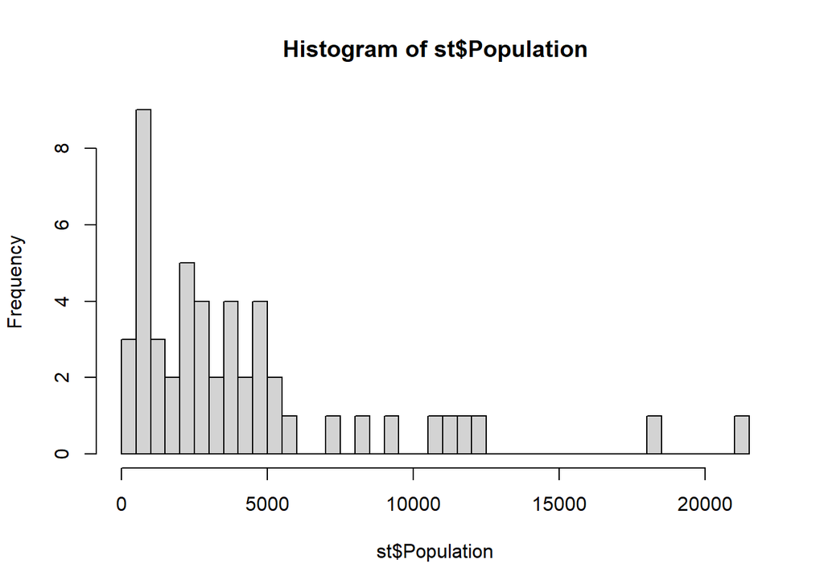

```r
hist(st$Population, breaks=30)
```

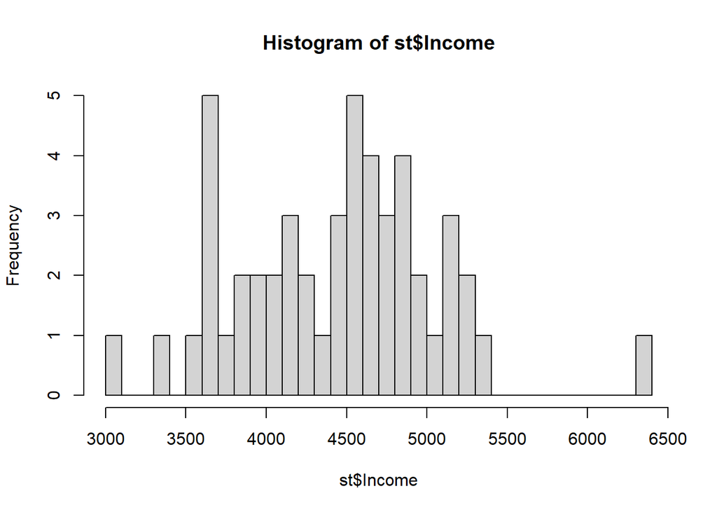

```r
hist(st$Income, breaks=30)
```

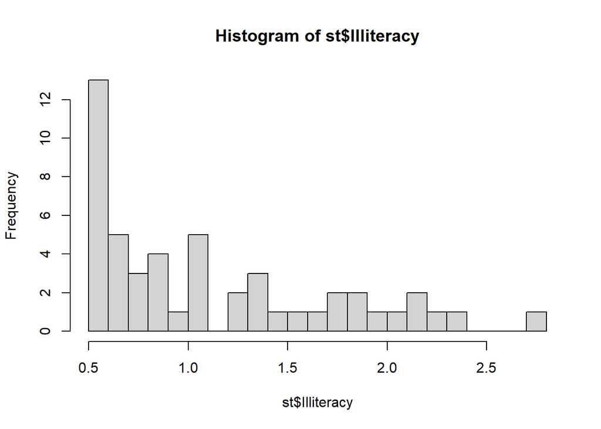

```r
hist(st$Illiteracy, breaks=30)
```

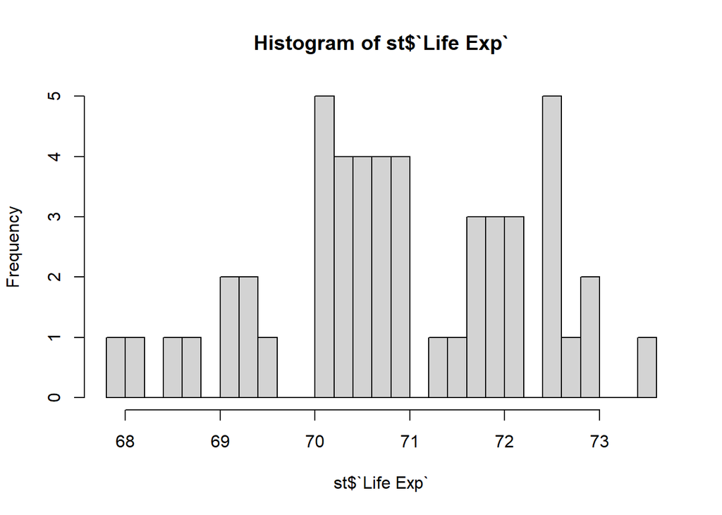

```r
hist(st$`Life Exp`, breaks=30)
```

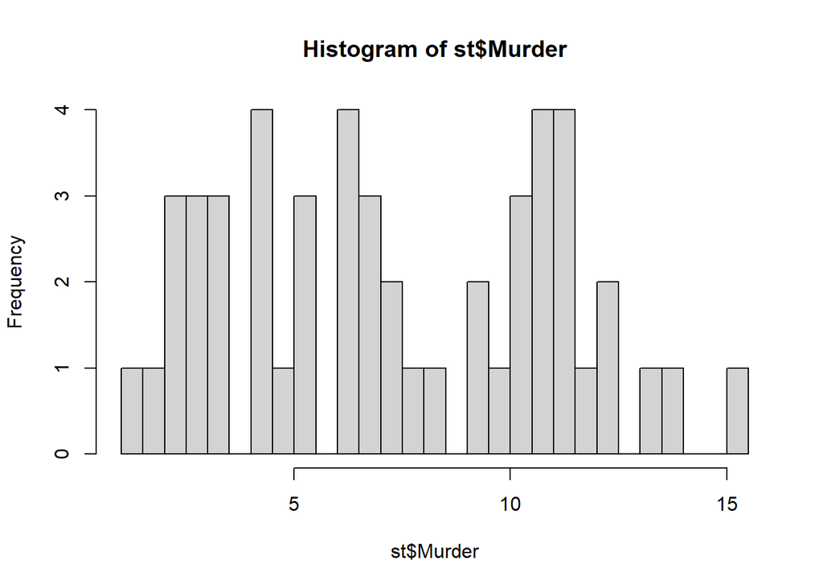

```r
hist(st$Murder, breaks=30)
```

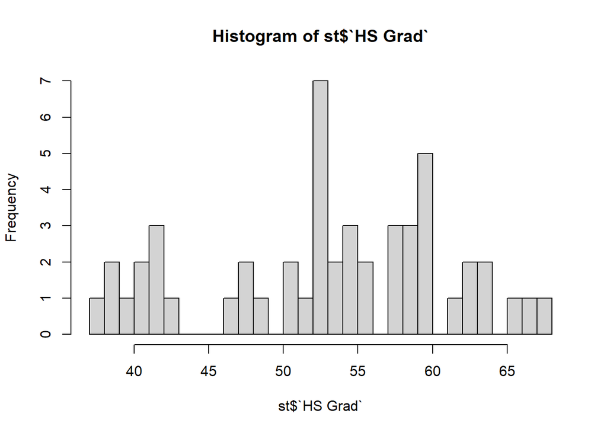

```r
hist(st$`HS Grad`, breaks=30)
```

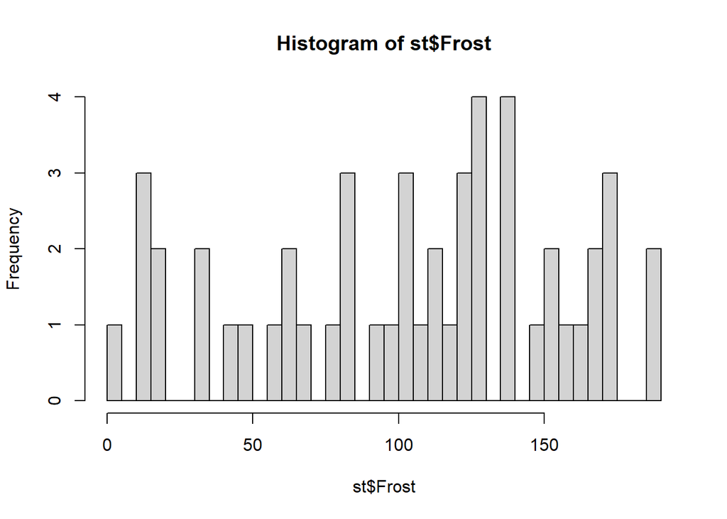

```r
hist(st$Frost, breaks=30)
```

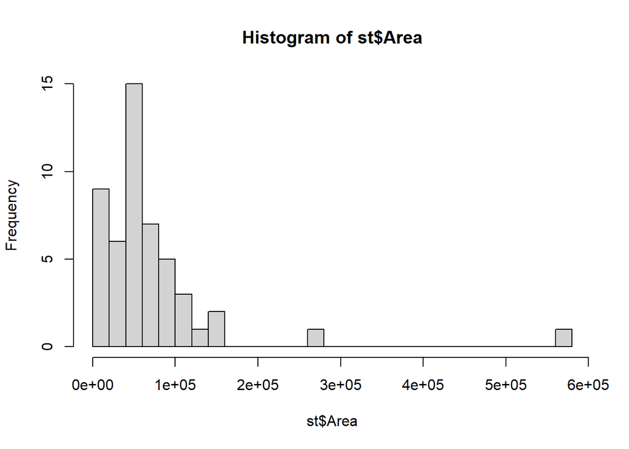

```r
hist(st$Area, breaks=30)
```

#### state.x77 데이터셋의 각 변수간의 관계에 대해 분석하고 시각화하시오.

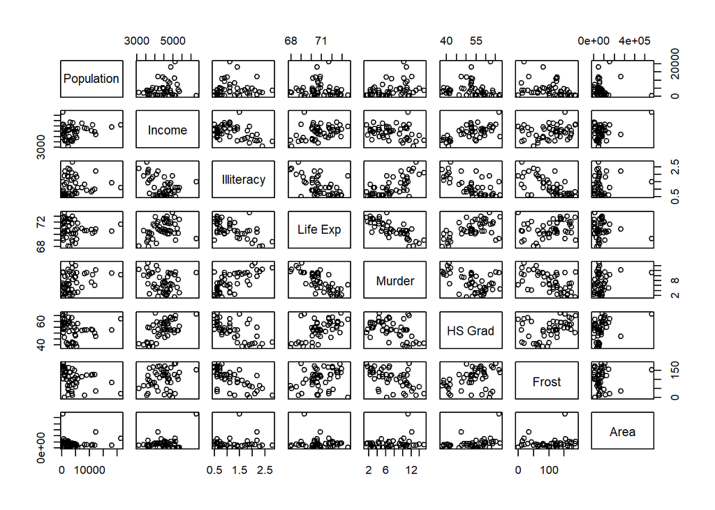

```r
pairs(st)
```

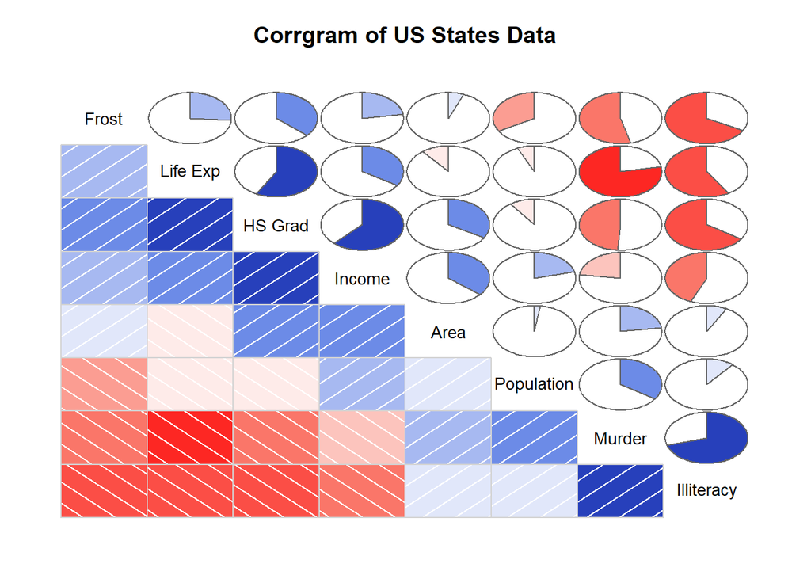

```r
# 양, 음의 상관관계 색깔표시
#install.packages('corrgram')
library(corrgram)
windows(width=7.0, height=7.0)
corrgram(state.x77,
         main="Corrgram of US States Data",
         order=TRUE,
         lower.panel=panel.shade,
         upper.panel=panel.pie,
         text.panel=panel.txt)
```

```r
mode = lm(Income ~ Population + Illiteracy+ `Life Exp`+ Murder + `HS Grad` + Frost + Area, data = st)
mode1 <- lm(Income ~ Population , data = st)
mode2 <- lm(Income ~ Illiteracy, data = st) #회귀계수가 -440.6  이므로 종속변수에 영향을 크게 미침
mode3 <- lm(Income ~ `Life Exp`, data = st) #회귀계수가 155.7  이므로 종속변수에 영향을 크게 미침
mode4 <- lm(Income ~ Murder, data = st)
mode5 <- lm(Income ~ `HS Grad`, data = st)
mode6 <- lm(Income ~ Frost, data = st)
mode7 <- lm(Income ~ Area, data = st)
```

```r
summary(mode2)
```

```
##
## Call:
## lm(formula = Income ~ Illiteracy, data = st)
##
## Residuals:
##     Min      1Q  Median      3Q     Max
## -948.89 -376.20  -49.77  347.00 2024.60
##
## Coefficients:
##             Estimate Std. Error t value Pr(>|t|)
## (Intercept)   4951.3      172.3  28.739  < 2e-16 ***
## Illiteracy    -440.6      130.9  -3.367  0.00151 **
## ---
## Signif. codes:  0 '***' 0.001 '**' 0.01 '*' 0.05 '.' 0.1 ' ' 1
##
## Residual standard error: 558.4 on 48 degrees of freedom
## Multiple R-squared:  0.191,  Adjusted R-squared:  0.1742
## F-statistic: 11.34 on 1 and 48 DF,  p-value: 0.001505
```

```r
# 독립변수의 pvalue가 매우 작으므로 독립변수가 유의한 영향을 미친다고 볼 수있음
# 회귀 모델의 pvalue도 작으므로 모델이 유의하다고 볼 수 있음
```

```r
summary(mode3)
```

```
##
## Call:
## lm(formula = Income ~ `Life Exp`, data = st)
##
## Residuals:
##      Min       1Q   Median       3Q      Max
## -1023.75  -467.39   -34.34   339.73  2123.51
##
## Coefficients:
##             Estimate Std. Error t value Pr(>|t|)
## (Intercept) -6603.48    4404.26  -1.499   0.1403
## `Life Exp`    155.75      62.13   2.507   0.0156 *
## ---
## Signif. codes:  0 '***' 0.001 '**' 0.01 '*' 0.05 '.' 0.1 ' ' 1
##
## Residual standard error: 583.8 on 48 degrees of freedom
## Multiple R-squared:  0.1158, Adjusted R-squared:  0.09735
## F-statistic: 6.285 on 1 and 48 DF,  p-value: 0.01562
```

```r
# 독립변수의 pvalue가 작으므로 독립변수가 유의한 영향을 미친다고 볼 수있음
# 회귀 모델의 pvalue도 작으므로 모델이 유의하다고 볼 수 있음
```

```r
summary(mode)
```

```
##
## Call:
## lm(formula = Income ~ Population + Illiteracy + `Life Exp` +
##     Murder + `HS Grad` + Frost + Area, data = st)
##
## Residuals:
##     Min      1Q  Median      3Q     Max
## -899.73 -226.98  -53.63  232.37  966.02
##
## Coefficients:
##               Estimate Std. Error t value Pr(>|t|)
## (Intercept)  3.183e+03  6.980e+03   0.456   0.6508
## Population   3.999e-02  1.808e-02   2.212   0.0325 *
## Illiteracy  -1.437e+02  2.302e+02  -0.624   0.5359
## `Life Exp`  -8.688e+00  9.739e+01  -0.089   0.9293
## Murder      -1.154e+01  4.151e+01  -0.278   0.7823
## `HS Grad`    3.417e+01  1.455e+01   2.349   0.0236 *
## Frost        1.916e-01  2.061e+00   0.093   0.9264
## Area         1.662e-03  1.021e-03   1.627   0.1111
## ---
## Signif. codes:  0 '***' 0.001 '**' 0.01 '*' 0.05 '.' 0.1 ' ' 1
##
## Residual standard error: 470.1 on 42 degrees of freedom
## Multiple R-squared:  0.4983, Adjusted R-squared:  0.4146
## F-statistic: 5.958 on 7 and 42 DF,  p-value: 7.485e-05
```

```r
# 독립변수 중 Population, HS Grad의  pvalue가 0.5보다 작으므로 두 독립변수가 유의한 영향을 미친다고 볼 수있음
# 회귀 모델의 pvalue는 매우 작으므로 모델이 유의하다고 볼 수 있음
# 회귀 모델의 pvalue가 가장 작으므로 세가지 모델 중 통계적으로 가장 유의한 모델이라고 볼 수있음.
```

#### state.x77 데이터셋을 대상으로 통계적 분석을 실행하고 통계적 분석을 통해 얻은 분석 결과를 기술하시오. 예 ) 변수간 상관관계가 가장 높은 두 변수는 Murder 와 Illiteracy 이다.

```r
cor(st)
```

```
##             Population     Income  Illiteracy    Life Exp     Murder
## Population  1.00000000  0.2082276  0.10762237 -0.06805195  0.3436428
## Income      0.20822756  1.0000000 -0.43707519  0.34025534 -0.2300776
## Illiteracy  0.10762237 -0.4370752  1.00000000 -0.58847793  0.7029752
## Life Exp   -0.06805195  0.3402553 -0.58847793  1.00000000 -0.7808458
## Murder      0.34364275 -0.2300776  0.70297520 -0.78084575  1.0000000
## HS Grad    -0.09848975  0.6199323 -0.65718861  0.58221620 -0.4879710
## Frost      -0.33215245  0.2262822 -0.67194697  0.26206801 -0.5388834
## Area        0.02254384  0.3633154  0.07726113 -0.10733194  0.2283902
##                HS Grad      Frost        Area
## Population -0.09848975 -0.3321525  0.02254384
## Income      0.61993232  0.2262822  0.36331544
## Illiteracy -0.65718861 -0.6719470  0.07726113
## Life Exp    0.58221620  0.2620680 -0.10733194
## Murder     -0.48797102 -0.5388834  0.22839021
## HS Grad     1.00000000  0.3667797  0.33354187
## Frost       0.36677970  1.0000000  0.05922910
## Area        0.33354187  0.0592291  1.00000000
```

```r
#분석 결과
#가장 상관관계가 높은 변수는 Murder,Life Exp 이고 음의상관관계를 가진다.
#상관계수-0.78이다.
```

## 5장 (1번, 2번)

### 1. 이산확률변수 X의 확률분포가 다음과 같다. 물음에 답하라.

| X | -2 | -1 | 0 | 1 | 2 |
| --- | --- | --- | --- | --- | --- |
| P(X=x) | 0.15 | 0.25 |  | 0.25 | 0.30 |

#### (1) P(X=0)을 구하라.

```r
x <- c(-2,-1,0,1,2)
p <- c(0.15, 0.25,0,0.25,0.30)
p[3] = 1-sum(p)
p[3]
```

```
## [1] 0.05
```

#### (2) 평균 $\mu$와 분산 $\sigma^2$을 구하라.

```r
#평균
mean = sum(x *p)
mean
```

```
## [1] 0.3
```

```r
#분산
var=sum(x*x*p)-mean^2
var
```

```
## [1] 2.21
```

### 2. X ~ B(8,0.45)에 대하여 다음을 구하라.

#### (1) P(X=4)

```r
dbinom(4, 8, 0.45)
```

```
## [1] 0.262663
```

#### (2) P(X $\neq$ 3)

```r
1-dbinom(3, 8, 0.45)
```

```
## [1] 0.743174
```

#### (3) P(X $\leq$ 5)

```r
pbinom(5, 8, 0.45, lower.tail = T)
```

```
## [1] 0.9115441
```

#### (4) P(X $\geq$ 6)

```r
pbinom(6, 8, 0.45, lower.tail = F) + dbinom(6, 8, 0.45)
```

```
## [1] 0.08845586
```

#### (5) 평균 $\mu$

```r
mean <- 8 * 0.45
mean
```

```
## [1] 3.6
```

#### (6) 분산 $\sigma$

```r
var = 8*0.45*(1-0.45)
var
```

```
## [1] 1.98
```

#### (7) P($\mu$ - $\sigma$ $\leq$ X $\leq$ $\mu$ + $\sigma$)

```r
pbinom(mean+sqrt(var), 8, 0.45) - pbinom(mean-sqrt(var), 8, 0.45)
```

```
## [1] 0.6914138
```

#### (8) P($\mu$ - 2 $\sigma$ $\leq$ X $\leq$ $\mu$ + 2$\sigma$)

```r
pbinom(mean+2*sqrt(var), 8, 0.45) - pbinom(mean-2*sqrt(var), 8, 0.45)
```

```
## [1] 0.9735036
```

## 6장 (1번, 2번)

### 1. 표준정규확률변수 Z에 대하여 다음을 구하라.

#### (1) P(Z $\geq$ 2.05)

```r
1-pnorm(2.05, 0, 1, lower.tail = T)
```

```
## [1] 0.02018222
```

#### (2) P(Z < 1.11)

```r
pnorm(1.11, 0, 1, lower.tail = T)
```

```
## [1] 0.8665005
```

#### (3) P(Z > -1.27)

```r
pnorm(-1.27, 0, 1, lower.tail = F)
```

```
## [1] 0.8979577
```

#### (4) P(-1.02 $\leq$ Z $\leq$ 1.02)

```r
pnorm(1.02, 0, 1) - pnorm(-1.02, 0, 1)
```

```
## [1] 0.6922715
```

### 2. X ~ N(5,4)일 때, 다음을 구하라.

#### (1) P(X $\geq$ 4.5)

```r
pnorm(4.5, 5, 2, lower.tail = F)
```

```
## [1] 0.5987063
```

#### (2) P(X < 6.5)

```r
pnorm(6.5, 5, 2)
```

```
## [1] 0.7733726
```

#### (3) P(X $\leq$ 2.5)

```r
pnorm(2.5, 5, 2)
```

```
## [1] 0.1056498
```

#### (4) P(3 $\leq$ X $\leq$ 7)

```r
pnorm(7, 5, 2) - pnorm(3, 5, 2)
```

```
## [1] 0.6826895
```

## 7장 (3번, 4번)

### 1. $\mu$ = 50이고 모표준편차가 다음과 같은 모집단으로부터 크기 25인 확률표본을 선정할 때, 표본평균이 49와 52 사이일 확률을 구하라.

#### (1) $\sigma$ = 4

```r
pnorm(52, 50, 4/5) - pnorm(49, 50, 4/5)
```

```
## [1] 0.8881406
```

#### (2) $\sigma$ = 9

```r
pnorm(52, 50, 9/5) - pnorm(49, 50, 9/5)
```

```
## [1] 0.5774824
```

#### (3) $\sigma$ = 12

```r
pnorm(52, 50, 12/5) - pnorm(49, 50, 12/5)
```

```
## [1] 0.4592105
```

### 2. $\mu$ = 50이고 모표준편차 $\sigma$인 정규모집단으로부터 다음과 같은 크기 n인 확률표본을 선정할 때, 표본평균이 49와 51 사이일 확률을 구하라.

#### (1) n = 16

```r
pnorm(51, 50, 5/4) - pnorm(49, 50, 5/4)
```

```
## [1] 0.5762892
```

#### (2) n = 49

```r
pnorm(51, 50, 5/7) - pnorm(49, 50, 5/7)
```

```
## [1] 0.8384867
```

#### (3) n = 64

```r
pnorm(51, 50, 5/8) - pnorm(49, 50, 5/8)
```

```
## [1] 0.8904014
```

## 8장 (1번, 2번)

### 1. 모분산이 다음과 같은 정규모집단의 모평균에 대한 95% 신뢰도를 갖는 구간을 추정하기 위하여 크기가 50인 표본을 선정한다. 이때 오차한계를 구하라.

#### (1) $\sigma^2$ = 5

```r
1.96*sqrt(5/50)
```

```
## [1] 0.6198064
```

#### (2) $\sigma^2$ = 15

```r
1.96*sqrt(15/50)
```

```
## [1] 1.073536
```

#### (3) $\sigma^2$ = 25

```r
1.96*sqrt(25/50)
```

```
## [1] 1.385929
```

#### (4) $\sigma^2$ = 35

```r
1.96*sqrt(35/50)
```

```
## [1] 1.639854
```

### 2. 모분산 4인 정규모집단의 모평균에 대한 95% 신뢰도를 갖는 구간을 추정하기 위하여 다음과 같은 크기의 표본을 선정한다. 이때 오차한계를 구하라.

#### (1) n = 50

```r
1.96*sqrt(4/50)
```

```
## [1] 0.5543717
```

#### (2) n = 100

```r
1.96*sqrt(4/100)
```

```
## [1] 0.392
```

#### (3) n = 200

```r
1.96*sqrt(4/200)
```

```
## [1] 0.2771859
```

#### (4) n = 500

```r
1.96*sqrt(4/500)
```

```
## [1] 0.1753077
```